# Risk Factor Analysis

## Outcome Variable

**Outcome Variable:** ever_co

## Predictor Variables

**Intervention Variable:** enstunt

**Adjustment Set:**

unadjusted

## Stratifying Variables

The analysis was stratified on these variable(s):

- agecat
- studyid
- country

## Data Summary

| agecat | studyid | country | enstunt | ever_co | n_cell | n |
| --- | --- | --- | --- | --- | --- | --- |
| 0-24 months | CMC-V-BCS-2002 | INDIA | 0 | 0 | 248 | 373 |
| 0-24 months | CMC-V-BCS-2002 | INDIA | 0 | 1 | 48 | 373 |
| 0-24 months | CMC-V-BCS-2002 | INDIA | 1 | 0 | 39 | 373 |
| 0-24 months | CMC-V-BCS-2002 | INDIA | 1 | 1 | 38 | 373 |
| 0-24 months | CMIN | BANGLADESH | 0 | 0 | 125 | 271 |
| 0-24 months | CMIN | BANGLADESH | 0 | 1 | 43 | 271 |
| 0-24 months | CMIN | BANGLADESH | 1 | 0 | 54 | 271 |
| 0-24 months | CMIN | BANGLADESH | 1 | 1 | 49 | 271 |
| 0-24 months | COHORTS | GUATEMALA | 0 | 0 | 934 | 1349 |
| 0-24 months | COHORTS | GUATEMALA | 0 | 1 | 91 | 1349 |
| 0-24 months | COHORTS | GUATEMALA | 1 | 0 | 266 | 1349 |
| 0-24 months | COHORTS | GUATEMALA | 1 | 1 | 58 | 1349 |
| 0-24 months | COHORTS | INDIA | 0 | 0 | 6095 | 7402 |
| 0-24 months | COHORTS | INDIA | 0 | 1 | 393 | 7402 |
| 0-24 months | COHORTS | INDIA | 1 | 0 | 645 | 7402 |
| 0-24 months | COHORTS | INDIA | 1 | 1 | 269 | 7402 |
| 0-24 months | COHORTS | PHILIPPINES | 0 | 0 | 2382 | 3045 |
| 0-24 months | COHORTS | PHILIPPINES | 0 | 1 | 485 | 3045 |
| 0-24 months | COHORTS | PHILIPPINES | 1 | 0 | 103 | 3045 |
| 0-24 months | COHORTS | PHILIPPINES | 1 | 1 | 75 | 3045 |
| 0-24 months | CONTENT | PERU | 0 | 0 | 195 | 215 |
| 0-24 months | CONTENT | PERU | 0 | 1 | 0 | 215 |
| 0-24 months | CONTENT | PERU | 1 | 0 | 20 | 215 |
| 0-24 months | CONTENT | PERU | 1 | 1 | 0 | 215 |
| 0-24 months | EE | PAKISTAN | 0 | 0 | 141 | 379 |
| 0-24 months | EE | PAKISTAN | 0 | 1 | 72 | 379 |
| 0-24 months | EE | PAKISTAN | 1 | 0 | 68 | 379 |
| 0-24 months | EE | PAKISTAN | 1 | 1 | 98 | 379 |
| 0-24 months | GMS-Nepal | NEPAL | 0 | 0 | 425 | 686 |
| 0-24 months | GMS-Nepal | NEPAL | 0 | 1 | 150 | 686 |

[output cut: 338 more lines]

The following strata were considered:

- agecat: 0-24 months, studyid: CMC-V-BCS-2002, country: INDIA
- agecat: 0-24 months, studyid: CMIN, country: BANGLADESH
- agecat: 0-24 months, studyid: COHORTS, country: GUATEMALA
- agecat: 0-24 months, studyid: COHORTS, country: INDIA
- agecat: 0-24 months, studyid: COHORTS, country: PHILIPPINES
- agecat: 0-24 months, studyid: CONTENT, country: PERU
- agecat: 0-24 months, studyid: EE, country: PAKISTAN
- agecat: 0-24 months, studyid: GMS-Nepal, country: NEPAL
- agecat: 0-24 months, studyid: Guatemala BSC, country: GUATEMALA
- agecat: 0-24 months, studyid: iLiNS-Zinc, country: BURKINA FASO
- agecat: 0-24 months, studyid: IRC, country: INDIA
- agecat: 0-24 months, studyid: JiVitA-3, country: BANGLADESH
- agecat: 0-24 months, studyid: JiVitA-4, country: BANGLADESH
- agecat: 0-24 months, studyid: Keneba, country: GAMBIA
- agecat: 0-24 months, studyid: LCNI-5, country: MALAWI
- agecat: 0-24 months, studyid: MAL-ED, country: BANGLADESH
- agecat: 0-24 months, studyid: MAL-ED, country: BRAZIL
- agecat: 0-24 months, studyid: MAL-ED, country: INDIA
- agecat: 0-24 months, studyid: MAL-ED, country: NEPAL
- agecat: 0-24 months, studyid: MAL-ED, country: PERU
- agecat: 0-24 months, studyid: MAL-ED, country: SOUTH AFRICA
- agecat: 0-24 months, studyid: MAL-ED, country: TANZANIA, UNITED REPUBLIC OF
- agecat: 0-24 months, studyid: NIH-Birth, country: BANGLADESH
- agecat: 0-24 months, studyid: NIH-Crypto, country: BANGLADESH
- agecat: 0-24 months, studyid: PROBIT, country: BELARUS
- agecat: 0-24 months, studyid: PROVIDE, country: BANGLADESH
- agecat: 0-24 months, studyid: ResPak, country: PAKISTAN
- agecat: 0-24 months, studyid: SAS-CompFeed, country: INDIA
- agecat: 0-24 months, studyid: SAS-FoodSuppl, country: INDIA
- agecat: 0-24 months, studyid: TanzaniaChild2, country: TANZANIA, UNITED REPUBLIC OF
- agecat: 0-24 months, studyid: ZVITAMBO, country: ZIMBABWE
- agecat: 0-6 months, studyid: CMC-V-BCS-2002, country: INDIA
- agecat: 0-6 months, studyid: CMIN, country: BANGLADESH
- agecat: 0-6 months, studyid: COHORTS, country: GUATEMALA
- agecat: 0-6 months, studyid: COHORTS, country: INDIA
- agecat: 0-6 months, studyid: COHORTS, country: PHILIPPINES
- agecat: 0-6 months, studyid: CONTENT, country: PERU
- agecat: 0-6 months, studyid: EE, country: PAKISTAN
- agecat: 0-6 months, studyid: GMS-Nepal, country: NEPAL
- agecat: 0-6 months, studyid: Guatemala BSC, country: GUATEMALA
- agecat: 0-6 months, studyid: IRC, country: INDIA
- agecat: 0-6 months, studyid: JiVitA-3, country: BANGLADESH
- agecat: 0-6 months, studyid: JiVitA-4, country: BANGLADESH
- agecat: 0-6 months, studyid: Keneba, country: GAMBIA
- agecat: 0-6 months, studyid: LCNI-5, country: MALAWI
- agecat: 0-6 months, studyid: MAL-ED, country: BANGLADESH
- agecat: 0-6 months, studyid: MAL-ED, country: BRAZIL
- agecat: 0-6 months, studyid: MAL-ED, country: INDIA
- agecat: 0-6 months, studyid: MAL-ED, country: NEPAL
- agecat: 0-6 months, studyid: MAL-ED, country: PERU
- agecat: 0-6 months, studyid: MAL-ED, country: SOUTH AFRICA
- agecat: 0-6 months, studyid: MAL-ED, country: TANZANIA, UNITED REPUBLIC OF
- agecat: 0-6 months, studyid: NIH-Birth, country: BANGLADESH
- agecat: 0-6 months, studyid: NIH-Crypto, country: BANGLADESH
- agecat: 0-6 months, studyid: PROBIT, country: BELARUS
- agecat: 0-6 months, studyid: PROVIDE, country: BANGLADESH
- agecat: 0-6 months, studyid: ResPak, country: PAKISTAN
- agecat: 0-6 months, studyid: SAS-CompFeed, country: INDIA
- agecat: 0-6 months, studyid: SAS-FoodSuppl, country: INDIA
- agecat: 0-6 months, studyid: TanzaniaChild2, country: TANZANIA, UNITED REPUBLIC OF
- agecat: 0-6 months, studyid: ZVITAMBO, country: ZIMBABWE
- agecat: 6-24 months, studyid: CMC-V-BCS-2002, country: INDIA
- agecat: 6-24 months, studyid: CMIN, country: BANGLADESH
- agecat: 6-24 months, studyid: COHORTS, country: GUATEMALA
- agecat: 6-24 months, studyid: COHORTS, country: INDIA
- agecat: 6-24 months, studyid: COHORTS, country: PHILIPPINES
- agecat: 6-24 months, studyid: CONTENT, country: PERU
- agecat: 6-24 months, studyid: EE, country: PAKISTAN
- agecat: 6-24 months, studyid: GMS-Nepal, country: NEPAL
- agecat: 6-24 months, studyid: Guatemala BSC, country: GUATEMALA
- agecat: 6-24 months, studyid: iLiNS-Zinc, country: BURKINA FASO
- agecat: 6-24 months, studyid: IRC, country: INDIA
- agecat: 6-24 months, studyid: JiVitA-3, country: BANGLADESH
- agecat: 6-24 months, studyid: JiVitA-4, country: BANGLADESH
- agecat: 6-24 months, studyid: Keneba, country: GAMBIA
- agecat: 6-24 months, studyid: LCNI-5, country: MALAWI
- agecat: 6-24 months, studyid: MAL-ED, country: BANGLADESH
- agecat: 6-24 months, studyid: MAL-ED, country: BRAZIL
- agecat: 6-24 months, studyid: MAL-ED, country: INDIA
- agecat: 6-24 months, studyid: MAL-ED, country: NEPAL
- agecat: 6-24 months, studyid: MAL-ED, country: PERU
- agecat: 6-24 months, studyid: MAL-ED, country: SOUTH AFRICA
- agecat: 6-24 months, studyid: MAL-ED, country: TANZANIA, UNITED REPUBLIC OF
- agecat: 6-24 months, studyid: NIH-Birth, country: BANGLADESH
- agecat: 6-24 months, studyid: NIH-Crypto, country: BANGLADESH
- agecat: 6-24 months, studyid: PROBIT, country: BELARUS
- agecat: 6-24 months, studyid: PROVIDE, country: BANGLADESH
- agecat: 6-24 months, studyid: ResPak, country: PAKISTAN
- agecat: 6-24 months, studyid: SAS-CompFeed, country: INDIA
- agecat: 6-24 months, studyid: SAS-FoodSuppl, country: INDIA
- agecat: 6-24 months, studyid: TanzaniaChild2, country: TANZANIA, UNITED REPUBLIC OF
- agecat: 6-24 months, studyid: ZVITAMBO, country: ZIMBABWE

### Dropped Strata

Some strata were dropped due to rare outcomes:

- agecat: 0-24 months, studyid: CONTENT, country: PERU
- agecat: 0-24 months, studyid: MAL-ED, country: BRAZIL
- agecat: 0-24 months, studyid: PROBIT, country: BELARUS
- agecat: 0-6 months, studyid: CMIN, country: BANGLADESH
- agecat: 0-6 months, studyid: COHORTS, country: GUATEMALA
- agecat: 0-6 months, studyid: CONTENT, country: PERU
- agecat: 0-6 months, studyid: Guatemala BSC, country: GUATEMALA
- agecat: 0-6 months, studyid: LCNI-5, country: MALAWI
- agecat: 0-6 months, studyid: MAL-ED, country: BANGLADESH
- agecat: 0-6 months, studyid: MAL-ED, country: BRAZIL
- agecat: 0-6 months, studyid: MAL-ED, country: NEPAL
- agecat: 0-6 months, studyid: MAL-ED, country: PERU
- agecat: 0-6 months, studyid: MAL-ED, country: SOUTH AFRICA
- agecat: 0-6 months, studyid: MAL-ED, country: TANZANIA, UNITED REPUBLIC OF
- agecat: 0-6 months, studyid: NIH-Crypto, country: BANGLADESH
- agecat: 0-6 months, studyid: PROBIT, country: BELARUS
- agecat: 0-6 months, studyid: ResPak, country: PAKISTAN
- agecat: 0-6 months, studyid: SAS-FoodSuppl, country: INDIA
- agecat: 6-24 months, studyid: CONTENT, country: PERU
- agecat: 6-24 months, studyid: MAL-ED, country: BRAZIL
- agecat: 6-24 months, studyid: MAL-ED, country: SOUTH AFRICA
- agecat: 6-24 months, studyid: PROBIT, country: BELARUS

## Methods Detail

We’re interested in the causal parameters $E[Y_a]$ for all values of $a \in \mathcal{A}$. These parameters represent the mean outcome if, possibly contrary to fact, we intervened to set all units to have $A=a$. Under the randomization and positivity assumptions, these are identified by the statistical parameters $\psi_a=E_W[E_{Y|A,W}(Y|A=a,W)]$. In addition, we’re interested in the mean of $Y$, $E[Y]$ under no intervention (the observed mean). We will estimate these parameters by using SuperLearner to fit the relevant likelihood factors – $E_{Y|A,W}(Y|A=a,W)$ and $p(A=a|W)$, and then updating our likelihood fit using a joint TMLE.

For unadjusted analyses ($W=\{\}$), initial likelihoods were estimated using Lrnr_glm to estimate the simple $E(Y|A)$ and Lrnr_mean to estimate $p(A)$. For adjusted analyses, a small library containing Lrnr_glmnet, Lrnr_xgboost, and Lrnr_mean was used.

Having estimated these parameters, we will then use the delta method to estimate relative risks and attributable risks relative to a prespecified baseline level of $A$.

# Results Detail

## Results Plots

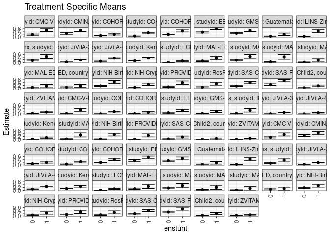

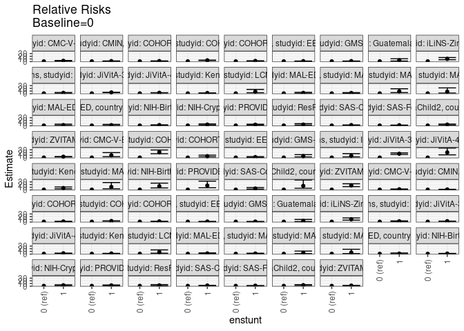

[figure not shown]

[figure not shown]

## Results Table

### Parameter: TSM

| agecat | studyid | country | intervention_level | baseline_level | estimate | ci_lower | ci_upper |
| --- | --- | --- | --- | --- | --- | --- | --- |
| 0-24 months | CMC-V-BCS-2002 | INDIA | 0 | NA | 0.1621622 | 0.1201147 | 0.2042096 |
| 0-24 months | CMC-V-BCS-2002 | INDIA | 1 | NA | 0.4935065 | 0.3816866 | 0.6053264 |
| 0-24 months | CMIN | BANGLADESH | 0 | NA | 0.2559524 | 0.1898410 | 0.3220638 |
| 0-24 months | CMIN | BANGLADESH | 1 | NA | 0.4757282 | 0.3791031 | 0.5723533 |
| 0-24 months | COHORTS | GUATEMALA | 0 | NA | 0.0887805 | 0.0713617 | 0.1061993 |
| 0-24 months | COHORTS | GUATEMALA | 1 | NA | 0.1790123 | 0.1372537 | 0.2207710 |
| 0-24 months | COHORTS | INDIA | 0 | NA | 0.0605734 | 0.0547685 | 0.0663783 |
| 0-24 months | COHORTS | INDIA | 1 | NA | 0.2943107 | 0.2647637 | 0.3238578 |
| 0-24 months | COHORTS | PHILIPPINES | 0 | NA | 0.1691664 | 0.1554411 | 0.1828916 |
| 0-24 months | COHORTS | PHILIPPINES | 1 | NA | 0.4213483 | 0.3487981 | 0.4938985 |
| 0-24 months | EE | PAKISTAN | 0 | NA | 0.3380282 | 0.2744178 | 0.4016386 |
| 0-24 months | EE | PAKISTAN | 1 | NA | 0.5903614 | 0.5154536 | 0.6652693 |
| 0-24 months | GMS-Nepal | NEPAL | 0 | NA | 0.2608696 | 0.2249523 | 0.2967868 |
| 0-24 months | GMS-Nepal | NEPAL | 1 | NA | 0.4684685 | 0.3755701 | 0.5613668 |
| 0-24 months | Guatemala BSC | GUATEMALA | 0 | NA | 0.0376569 | 0.0134841 | 0.0618297 |
| 0-24 months | Guatemala BSC | GUATEMALA | 1 | NA | 0.1842105 | 0.0969178 | 0.2715032 |
| 0-24 months | iLiNS-Zinc | BURKINA FASO | 0 | NA | 0.0402685 | 0.0297663 | 0.0507706 |
| 0-24 months | iLiNS-Zinc | BURKINA FASO | 1 | NA | 0.4166667 | 0.2980013 | 0.5353321 |
| 0-24 months | IRC | INDIA | 0 | NA | 0.1480447 | 0.1112113 | 0.1848781 |
| 0-24 months | IRC | INDIA | 1 | NA | 0.4423077 | 0.3071514 | 0.5774640 |
| 0-24 months | JiVitA-3 | BANGLADESH | 0 | NA | 0.0407186 | 0.0376330 | 0.0438042 |
| 0-24 months | JiVitA-3 | BANGLADESH | 1 | NA | 0.1922133 | 0.1830959 | 0.2013306 |
| 0-24 months | JiVitA-4 | BANGLADESH | 0 | NA | 0.0972723 | 0.0866318 | 0.1079127 |
| 0-24 months | JiVitA-4 | BANGLADESH | 1 | NA | 0.3213368 | 0.2947448 | 0.3479287 |
| 0-24 months | Keneba | GAMBIA | 0 | NA | 0.1262098 | 0.1134010 | 0.1390187 |
| 0-24 months | Keneba | GAMBIA | 1 | NA | 0.3212121 | 0.2708239 | 0.3716003 |
| 0-24 months | LCNI-5 | MALAWI | 0 | NA | 0.0150659 | 0.0046987 | 0.0254331 |
| 0-24 months | LCNI-5 | MALAWI | 1 | NA | 0.1132686 | 0.0779114 | 0.1486258 |
| 0-24 months | MAL-ED | BANGLADESH | 0 | NA | 0.1105991 | 0.0687901 | 0.1524081 |
| 0-24 months | MAL-ED | BANGLADESH | 1 | NA | 0.3260870 | 0.1903603 | 0.4618136 |

[output cut: 110 more lines]

### Parameter: E(Y)

| agecat | studyid | country | intervention_level | baseline_level | estimate | ci_lower | ci_upper |
| --- | --- | --- | --- | --- | --- | --- | --- |
| 0-24 months | CMC-V-BCS-2002 | INDIA | NA | NA | 0.2305630 | 0.1877616 | 0.2733644 |
| 0-24 months | CMIN | BANGLADESH | NA | NA | 0.3394834 | 0.2830004 | 0.3959663 |
| 0-24 months | COHORTS | GUATEMALA | NA | NA | 0.1104522 | 0.0937191 | 0.1271852 |
| 0-24 months | COHORTS | INDIA | NA | NA | 0.0894353 | 0.0829338 | 0.0959368 |
| 0-24 months | COHORTS | PHILIPPINES | NA | NA | 0.1839080 | 0.1701456 | 0.1976705 |
| 0-24 months | EE | PAKISTAN | NA | NA | 0.4485488 | 0.3984116 | 0.4986861 |
| 0-24 months | GMS-Nepal | NEPAL | NA | NA | 0.2944606 | 0.2603274 | 0.3285938 |
| 0-24 months | Guatemala BSC | GUATEMALA | NA | NA | 0.0730159 | 0.0442400 | 0.1017917 |
| 0-24 months | iLiNS-Zinc | BURKINA FASO | NA | NA | 0.1246554 | 0.1041227 | 0.1451882 |
| 0-24 months | IRC | INDIA | NA | NA | 0.1853659 | 0.1477057 | 0.2230261 |
| 0-24 months | JiVitA-3 | BANGLADESH | NA | NA | 0.0888460 | 0.0849398 | 0.0927521 |
| 0-24 months | JiVitA-4 | BANGLADESH | NA | NA | 0.1613377 | 0.1500062 | 0.1726692 |
| 0-24 months | Keneba | GAMBIA | NA | NA | 0.1483007 | 0.1353925 | 0.1612090 |
| 0-24 months | LCNI-5 | MALAWI | NA | NA | 0.0511905 | 0.0362780 | 0.0661030 |
| 0-24 months | MAL-ED | BANGLADESH | NA | NA | 0.1482890 | 0.1052563 | 0.1913216 |
| 0-24 months | MAL-ED | INDIA | NA | NA | 0.2151394 | 0.1642023 | 0.2660766 |
| 0-24 months | MAL-ED | NEPAL | NA | NA | 0.0916667 | 0.0550838 | 0.1282495 |
| 0-24 months | MAL-ED | PERU | NA | NA | 0.0397351 | 0.0176679 | 0.0618023 |
| 0-24 months | MAL-ED | SOUTH AFRICA | NA | NA | 0.0737179 | 0.0446760 | 0.1027599 |
| 0-24 months | MAL-ED | TANZANIA, UNITED REPUBLIC OF | NA | NA | 0.0881226 | 0.0536659 | 0.1225793 |
| 0-24 months | NIH-Birth | BANGLADESH | NA | NA | 0.2195513 | 0.1870467 | 0.2520558 |
| 0-24 months | NIH-Crypto | BANGLADESH | NA | NA | 0.0936675 | 0.0729118 | 0.1144233 |
| 0-24 months | PROVIDE | BANGLADESH | NA | NA | 0.1285714 | 0.1037574 | 0.1533855 |
| 0-24 months | ResPak | PAKISTAN | NA | NA | 0.1478873 | 0.1065284 | 0.1892462 |
| 0-24 months | SAS-CompFeed | INDIA | NA | NA | 0.2319894 | 0.1917264 | 0.2722524 |
| 0-24 months | SAS-FoodSuppl | INDIA | NA | NA | 0.3708134 | 0.3244530 | 0.4171738 |
| 0-24 months | TanzaniaChild2 | TANZANIA, UNITED REPUBLIC OF | NA | NA | 0.0496661 | 0.0409652 | 0.0583670 |
| 0-24 months | ZVITAMBO | ZIMBABWE | NA | NA | 0.0423899 | 0.0390454 | 0.0457344 |
| 0-6 months | CMC-V-BCS-2002 | INDIA | NA | NA | 0.0842391 | 0.0558231 | 0.1126551 |
| 0-6 months | COHORTS | INDIA | NA | NA | 0.0259576 | 0.0222658 | 0.0296495 |
| 0-6 months | COHORTS | PHILIPPINES | NA | NA | 0.0236531 | 0.0182537 | 0.0290525 |
| 0-6 months | EE | PAKISTAN | NA | NA | 0.1503958 | 0.1143605 | 0.1864311 |
| 0-6 months | GMS-Nepal | NEPAL | NA | NA | 0.0524781 | 0.0357793 | 0.0691770 |
| 0-6 months | IRC | INDIA | NA | NA | 0.0611247 | 0.0378797 | 0.0843697 |
| 0-6 months | JiVitA-3 | BANGLADESH | NA | NA | 0.0396778 | 0.0371765 | 0.0421791 |
| 0-6 months | JiVitA-4 | BANGLADESH | NA | NA | 0.0265122 | 0.0211694 | 0.0318550 |
| 0-6 months | Keneba | GAMBIA | NA | NA | 0.0284322 | 0.0218657 | 0.0349987 |
| 0-6 months | MAL-ED | INDIA | NA | NA | 0.0756972 | 0.0429084 | 0.1084860 |
| 0-6 months | NIH-Birth | BANGLADESH | NA | NA | 0.0723473 | 0.0519719 | 0.0927227 |
| 0-6 months | PROVIDE | BANGLADESH | NA | NA | 0.0428571 | 0.0278427 | 0.0578716 |
| 0-6 months | SAS-CompFeed | INDIA | NA | NA | 0.0704787 | 0.0478990 | 0.0930584 |
| 0-6 months | TanzaniaChild2 | TANZANIA, UNITED REPUBLIC OF | NA | NA | 0.0079299 | 0.0043777 | 0.0114821 |
| 0-6 months | ZVITAMBO | ZIMBABWE | NA | NA | 0.0120612 | 0.0102430 | 0.0138795 |
| 6-24 months | CMC-V-BCS-2002 | INDIA | NA | NA | 0.1876676 | 0.1479906 | 0.2273445 |
| 6-24 months | CMIN | BANGLADESH | NA | NA | 0.3426295 | 0.2837999 | 0.4014590 |
| 6-24 months | COHORTS | GUATEMALA | NA | NA | 0.1116585 | 0.0939639 | 0.1293530 |
| 6-24 months | COHORTS | INDIA | NA | NA | 0.0831652 | 0.0766672 | 0.0896632 |
| 6-24 months | COHORTS | PHILIPPINES | NA | NA | 0.1908832 | 0.1763448 | 0.2054216 |
| 6-24 months | EE | PAKISTAN | NA | NA | 0.4193548 | 0.3691429 | 0.4695668 |
| 6-24 months | GMS-Nepal | NEPAL | NA | NA | 0.3254237 | 0.2875855 | 0.3632619 |
| 6-24 months | Guatemala BSC | GUATEMALA | NA | NA | 0.0649819 | 0.0359016 | 0.0940623 |
| 6-24 months | iLiNS-Zinc | BURKINA FASO | NA | NA | 0.1246554 | 0.1041227 | 0.1451882 |
| 6-24 months | IRC | INDIA | NA | NA | 0.1560976 | 0.1209228 | 0.1912723 |
| 6-24 months | JiVitA-3 | BANGLADESH | NA | NA | 0.0869213 | 0.0822621 | 0.0915805 |
| 6-24 months | JiVitA-4 | BANGLADESH | NA | NA | 0.1477252 | 0.1371297 | 0.1583206 |
| 6-24 months | Keneba | GAMBIA | NA | NA | 0.1469835 | 0.1337108 | 0.1602563 |
| 6-24 months | LCNI-5 | MALAWI | NA | NA | 0.0520581 | 0.0368996 | 0.0672166 |
| 6-24 months | MAL-ED | BANGLADESH | NA | NA | 0.1464435 | 0.1015265 | 0.1913605 |
| 6-24 months | MAL-ED | INDIA | NA | NA | 0.2000000 | 0.1487493 | 0.2512507 |
| 6-24 months | MAL-ED | NEPAL | NA | NA | 0.0680851 | 0.0358110 | 0.1003592 |
| 6-24 months | MAL-ED | PERU | NA | NA | 0.0407407 | 0.0171167 | 0.0643648 |
| 6-24 months | MAL-ED | TANZANIA, UNITED REPUBLIC OF | NA | NA | 0.0857143 | 0.0505889 | 0.1208396 |
| 6-24 months | NIH-Birth | BANGLADESH | NA | NA | 0.2103321 | 0.1759902 | 0.2446740 |
| 6-24 months | NIH-Crypto | BANGLADESH | NA | NA | 0.0863014 | 0.0659171 | 0.1066856 |
| 6-24 months | PROVIDE | BANGLADESH | NA | NA | 0.1221498 | 0.0962275 | 0.1480722 |
| 6-24 months | ResPak | PAKISTAN | NA | NA | 0.1313559 | 0.0881682 | 0.1745436 |
| 6-24 months | SAS-CompFeed | INDIA | NA | NA | 0.2260619 | 0.1909133 | 0.2612105 |
| 6-24 months | SAS-FoodSuppl | INDIA | NA | NA | 0.3615960 | 0.3145115 | 0.4086805 |
| 6-24 months | TanzaniaChild2 | TANZANIA, UNITED REPUBLIC OF | NA | NA | 0.0560238 | 0.0459853 | 0.0660623 |
| 6-24 months | ZVITAMBO | ZIMBABWE | NA | NA | 0.0410617 | 0.0373214 | 0.0448020 |

### Parameter: RR

| agecat | studyid | country | intervention_level | baseline_level | estimate | ci_lower | ci_upper |
| --- | --- | --- | --- | --- | --- | --- | --- |
| 0-24 months | CMC-V-BCS-2002 | INDIA | 0 | 0 | 1.000000 | 1.0000000 | 1.000000 |
| 0-24 months | CMC-V-BCS-2002 | INDIA | 1 | 0 | 3.043290 | 2.1567358 | 4.294274 |
| 0-24 months | CMIN | BANGLADESH | 0 | 0 | 1.000000 | 1.0000000 | 1.000000 |
| 0-24 months | CMIN | BANGLADESH | 1 | 0 | 1.858659 | 1.3381217 | 2.581688 |
| 0-24 months | COHORTS | GUATEMALA | 0 | 0 | 1.000000 | 1.0000000 | 1.000000 |
| 0-24 months | COHORTS | GUATEMALA | 1 | 0 | 2.016348 | 1.4865759 | 2.734915 |
| 0-24 months | COHORTS | INDIA | 0 | 0 | 1.000000 | 1.0000000 | 1.000000 |
| 0-24 months | COHORTS | INDIA | 1 | 0 | 4.858748 | 4.2291042 | 5.582135 |
| 0-24 months | COHORTS | PHILIPPINES | 0 | 0 | 1.000000 | 1.0000000 | 1.000000 |
| 0-24 months | COHORTS | PHILIPPINES | 1 | 0 | 2.490733 | 2.0590266 | 3.012954 |
| 0-24 months | EE | PAKISTAN | 0 | 0 | 1.000000 | 1.0000000 | 1.000000 |
| 0-24 months | EE | PAKISTAN | 1 | 0 | 1.746486 | 1.3918639 | 2.191459 |
| 0-24 months | GMS-Nepal | NEPAL | 0 | 0 | 1.000000 | 1.0000000 | 1.000000 |
| 0-24 months | GMS-Nepal | NEPAL | 1 | 0 | 1.795796 | 1.4106280 | 2.286132 |
| 0-24 months | Guatemala BSC | GUATEMALA | 0 | 0 | 1.000000 | 1.0000000 | 1.000000 |
| 0-24 months | Guatemala BSC | GUATEMALA | 1 | 0 | 4.891813 | 2.2026861 | 10.863933 |
| 0-24 months | iLiNS-Zinc | BURKINA FASO | 0 | 0 | 1.000000 | 1.0000000 | 1.000000 |
| 0-24 months | iLiNS-Zinc | BURKINA FASO | 1 | 0 | 10.347222 | 7.0368104 | 15.214991 |
| 0-24 months | IRC | INDIA | 0 | 0 | 1.000000 | 1.0000000 | 1.000000 |
| 0-24 months | IRC | INDIA | 1 | 0 | 2.987663 | 2.0146445 | 4.430624 |
| 0-24 months | JiVitA-3 | BANGLADESH | 0 | 0 | 1.000000 | 1.0000000 | 1.000000 |
| 0-24 months | JiVitA-3 | BANGLADESH | 1 | 0 | 4.720531 | 4.3377462 | 5.137096 |
| 0-24 months | JiVitA-4 | BANGLADESH | 0 | 0 | 1.000000 | 1.0000000 | 1.000000 |
| 0-24 months | JiVitA-4 | BANGLADESH | 1 | 0 | 3.303478 | 2.8858761 | 3.781509 |
| 0-24 months | Keneba | GAMBIA | 0 | 0 | 1.000000 | 1.0000000 | 1.000000 |
| 0-24 months | Keneba | GAMBIA | 1 | 0 | 2.545064 | 2.1113332 | 3.067896 |
| 0-24 months | LCNI-5 | MALAWI | 0 | 0 | 1.000000 | 1.0000000 | 1.000000 |
| 0-24 months | LCNI-5 | MALAWI | 1 | 0 | 7.518204 | 3.5314685 | 16.005633 |
| 0-24 months | MAL-ED | BANGLADESH | 0 | 0 | 1.000000 | 1.0000000 | 1.000000 |
| 0-24 months | MAL-ED | BANGLADESH | 1 | 0 | 2.948370 | 1.6803167 | 5.173360 |

[output cut: 110 more lines]

### Parameter: PAR

| agecat | studyid | country | intervention_level | baseline_level | estimate | ci_lower | ci_upper |
| --- | --- | --- | --- | --- | --- | --- | --- |
| 0-24 months | CMC-V-BCS-2002 | INDIA | 0 | NA | 0.0684008 | 0.0402243 | 0.0965774 |
| 0-24 months | CMIN | BANGLADESH | 0 | NA | 0.0835310 | 0.0372493 | 0.1298127 |
| 0-24 months | COHORTS | GUATEMALA | 0 | NA | 0.0216717 | 0.0106115 | 0.0327319 |
| 0-24 months | COHORTS | INDIA | 0 | NA | 0.0288619 | 0.0247517 | 0.0329722 |
| 0-24 months | COHORTS | PHILIPPINES | 0 | NA | 0.0147417 | 0.0099409 | 0.0195424 |
| 0-24 months | EE | PAKISTAN | 0 | NA | 0.1105206 | 0.0656657 | 0.1553756 |
| 0-24 months | GMS-Nepal | NEPAL | 0 | NA | 0.0335911 | 0.0164883 | 0.0506939 |
| 0-24 months | Guatemala BSC | GUATEMALA | 0 | NA | 0.0353590 | 0.0124312 | 0.0582868 |
| 0-24 months | iLiNS-Zinc | BURKINA FASO | 0 | NA | 0.0843870 | 0.0655926 | 0.1031814 |
| 0-24 months | IRC | INDIA | 0 | NA | 0.0373212 | 0.0171784 | 0.0574639 |
| 0-24 months | JiVitA-3 | BANGLADESH | 0 | NA | 0.0481274 | 0.0450071 | 0.0512477 |
| 0-24 months | JiVitA-4 | BANGLADESH | 0 | NA | 0.0640655 | 0.0555081 | 0.0726229 |
| 0-24 months | Keneba | GAMBIA | 0 | NA | 0.0220909 | 0.0157878 | 0.0283939 |
| 0-24 months | LCNI-5 | MALAWI | 0 | NA | 0.0361246 | 0.0221970 | 0.0500522 |
| 0-24 months | MAL-ED | BANGLADESH | 0 | NA | 0.0376899 | 0.0109452 | 0.0644346 |
| 0-24 months | MAL-ED | INDIA | 0 | NA | 0.0437109 | 0.0147603 | 0.0726614 |
| 0-24 months | MAL-ED | NEPAL | 0 | NA | 0.0442733 | 0.0175828 | 0.0709638 |
| 0-24 months | MAL-ED | PERU | 0 | NA | 0.0171787 | 0.0015689 | 0.0327885 |
| 0-24 months | MAL-ED | SOUTH AFRICA | 0 | NA | 0.0116742 | -0.0033029 | 0.0266512 |
| 0-24 months | MAL-ED | TANZANIA, UNITED REPUBLIC OF | 0 | NA | 0.0150632 | -0.0043938 | 0.0345203 |
| 0-24 months | NIH-Birth | BANGLADESH | 0 | NA | 0.0434149 | 0.0254022 | 0.0614277 |
| 0-24 months | NIH-Crypto | BANGLADESH | 0 | NA | 0.0308804 | 0.0174564 | 0.0443044 |
| 0-24 months | PROVIDE | BANGLADESH | 0 | NA | 0.0290454 | 0.0158036 | 0.0422871 |
| 0-24 months | ResPak | PAKISTAN | 0 | NA | 0.0736299 | 0.0396266 | 0.1076332 |
| 0-24 months | SAS-CompFeed | INDIA | 0 | NA | 0.0694550 | 0.0511497 | 0.0877602 |
| 0-24 months | SAS-FoodSuppl | INDIA | 0 | NA | 0.1062220 | 0.0677550 | 0.1446890 |
| 0-24 months | TanzaniaChild2 | TANZANIA, UNITED REPUBLIC OF | 0 | NA | 0.0093616 | 0.0050962 | 0.0136269 |
| 0-24 months | ZVITAMBO | ZIMBABWE | 0 | NA | 0.0103663 | 0.0084656 | 0.0122669 |
| 0-6 months | CMC-V-BCS-2002 | INDIA | 0 | NA | 0.0534172 | 0.0294136 | 0.0774209 |
| 0-6 months | COHORTS | INDIA | 0 | NA | 0.0183204 | 0.0151437 | 0.0214971 |
| 0-6 months | COHORTS | PHILIPPINES | 0 | NA | 0.0055157 | 0.0026767 | 0.0083547 |
| 0-6 months | EE | PAKISTAN | 0 | NA | 0.0658887 | 0.0323469 | 0.0994306 |
| 0-6 months | GMS-Nepal | NEPAL | 0 | NA | 0.0246520 | 0.0121448 | 0.0371593 |
| 0-6 months | IRC | INDIA | 0 | NA | 0.0276051 | 0.0109089 | 0.0443014 |
| 0-6 months | JiVitA-3 | BANGLADESH | 0 | NA | 0.0325291 | 0.0301756 | 0.0348826 |
| 0-6 months | JiVitA-4 | BANGLADESH | 0 | NA | 0.0224082 | 0.0173104 | 0.0275060 |
| 0-6 months | Keneba | GAMBIA | 0 | NA | 0.0104466 | 0.0061454 | 0.0147477 |
| 0-6 months | MAL-ED | INDIA | 0 | NA | 0.0471258 | 0.0200723 | 0.0741792 |
| 0-6 months | NIH-Birth | BANGLADESH | 0 | NA | 0.0477261 | 0.0306074 | 0.0648447 |
| 0-6 months | PROVIDE | BANGLADESH | 0 | NA | 0.0254796 | 0.0135831 | 0.0373760 |
| 0-6 months | SAS-CompFeed | INDIA | 0 | NA | 0.0383096 | 0.0209566 | 0.0556626 |
| 0-6 months | TanzaniaChild2 | TANZANIA, UNITED REPUBLIC OF | 0 | NA | 0.0038994 | 0.0013207 | 0.0064781 |
| 0-6 months | ZVITAMBO | ZIMBABWE | 0 | NA | 0.0073394 | 0.0058754 | 0.0088033 |
| 6-24 months | CMC-V-BCS-2002 | INDIA | 0 | NA | 0.0423973 | 0.0173853 | 0.0674092 |
| 6-24 months | CMIN | BANGLADESH | 0 | NA | 0.0704776 | 0.0234803 | 0.1174748 |
| 6-24 months | COHORTS | GUATEMALA | 0 | NA | 0.0225495 | 0.0105503 | 0.0345488 |
| 6-24 months | COHORTS | INDIA | 0 | NA | 0.0207164 | 0.0169415 | 0.0244913 |
| 6-24 months | COHORTS | PHILIPPINES | 0 | NA | 0.0124333 | 0.0076275 | 0.0172390 |
| 6-24 months | EE | PAKISTAN | 0 | NA | 0.0987807 | 0.0537821 | 0.1437793 |
| 6-24 months | GMS-Nepal | NEPAL | 0 | NA | 0.0258286 | 0.0076868 | 0.0439703 |
| 6-24 months | Guatemala BSC | GUATEMALA | 0 | NA | 0.0270673 | 0.0047788 | 0.0493557 |
| 6-24 months | iLiNS-Zinc | BURKINA FASO | 0 | NA | 0.0843870 | 0.0655926 | 0.1031814 |
| 6-24 months | IRC | INDIA | 0 | NA | 0.0276059 | 0.0092140 | 0.0459979 |
| 6-24 months | JiVitA-3 | BANGLADESH | 0 | NA | 0.0335880 | 0.0300828 | 0.0370931 |
| 6-24 months | JiVitA-4 | BANGLADESH | 0 | NA | 0.0522659 | 0.0444701 | 0.0600617 |
| 6-24 months | Keneba | GAMBIA | 0 | NA | 0.0177122 | 0.0115530 | 0.0238714 |
| 6-24 months | LCNI-5 | MALAWI | 0 | NA | 0.0366141 | 0.0224339 | 0.0507942 |
| 6-24 months | MAL-ED | BANGLADESH | 0 | NA | 0.0270405 | 0.0017172 | 0.0523638 |
| 6-24 months | MAL-ED | INDIA | 0 | NA | 0.0274112 | 0.0003089 | 0.0545134 |
| 6-24 months | MAL-ED | NEPAL | 0 | NA | 0.0197759 | 0.0000540 | 0.0394979 |
| 6-24 months | MAL-ED | PERU | 0 | NA | 0.0153170 | -0.0006592 | 0.0312932 |
| 6-24 months | MAL-ED | TANZANIA, UNITED REPUBLIC OF | 0 | NA | 0.0080444 | -0.0098296 | 0.0259183 |
| 6-24 months | NIH-Birth | BANGLADESH | 0 | NA | 0.0239286 | 0.0064474 | 0.0414098 |
| 6-24 months | NIH-Crypto | BANGLADESH | 0 | NA | 0.0209106 | 0.0088120 | 0.0330093 |
| 6-24 months | PROVIDE | BANGLADESH | 0 | NA | 0.0188890 | 0.0063644 | 0.0314135 |
| 6-24 months | ResPak | PAKISTAN | 0 | NA | 0.0485157 | 0.0151154 | 0.0819160 |
| 6-24 months | SAS-CompFeed | INDIA | 0 | NA | 0.0620460 | 0.0448096 | 0.0792824 |
| 6-24 months | SAS-FoodSuppl | INDIA | 0 | NA | 0.0829075 | 0.0438102 | 0.1220048 |
| 6-24 months | TanzaniaChild2 | TANZANIA, UNITED REPUBLIC OF | 0 | NA | 0.0091904 | 0.0045044 | 0.0138763 |
| 6-24 months | ZVITAMBO | ZIMBABWE | 0 | NA | 0.0044498 | 0.0027349 | 0.0061647 |

### Parameter: PAF

| agecat | studyid | country | intervention_level | baseline_level | estimate | ci_lower | ci_upper |
| --- | --- | --- | --- | --- | --- | --- | --- |
| 0-24 months | CMC-V-BCS-2002 | INDIA | 0 | NA | 0.2966688 | 0.1719631 | 0.4025932 |
| 0-24 months | CMIN | BANGLADESH | 0 | NA | 0.2460533 | 0.0982840 | 0.3696068 |
| 0-24 months | COHORTS | GUATEMALA | 0 | NA | 0.1962089 | 0.0936324 | 0.2871764 |
| 0-24 months | COHORTS | INDIA | 0 | NA | 0.3227129 | 0.2810462 | 0.3619648 |
| 0-24 months | COHORTS | PHILIPPINES | 0 | NA | 0.0801578 | 0.0540980 | 0.1054997 |
| 0-24 months | EE | PAKISTAN | 0 | NA | 0.2463960 | 0.1384827 | 0.3407921 |
| 0-24 months | GMS-Nepal | NEPAL | 0 | NA | 0.1140766 | 0.0544687 | 0.1699268 |
| 0-24 months | Guatemala BSC | GUATEMALA | 0 | NA | 0.4842641 | 0.1540456 | 0.6855818 |
| 0-24 months | iLiNS-Zinc | BURKINA FASO | 0 | NA | 0.6769619 | 0.5876736 | 0.7469150 |
| 0-24 months | IRC | INDIA | 0 | NA | 0.2013378 | 0.0906633 | 0.2985423 |
| 0-24 months | JiVitA-3 | BANGLADESH | 0 | NA | 0.5416949 | 0.5136924 | 0.5680849 |
| 0-24 months | JiVitA-4 | BANGLADESH | 0 | NA | 0.3970893 | 0.3478267 | 0.4426307 |
| 0-24 months | Keneba | GAMBIA | 0 | NA | 0.1489601 | 0.1068654 | 0.1890708 |
| 0-24 months | LCNI-5 | MALAWI | 0 | NA | 0.7056891 | 0.4538749 | 0.8413937 |
| 0-24 months | MAL-ED | BANGLADESH | 0 | NA | 0.2541652 | 0.0647098 | 0.4052439 |
| 0-24 months | MAL-ED | INDIA | 0 | NA | 0.2031746 | 0.0623997 | 0.3228130 |
| 0-24 months | MAL-ED | NEPAL | 0 | NA | 0.4829815 | 0.1980653 | 0.6666709 |
| 0-24 months | MAL-ED | PERU | 0 | NA | 0.4323308 | 0.0107995 | 0.6742336 |
| 0-24 months | MAL-ED | SOUTH AFRICA | 0 | NA | 0.1583624 | -0.0606925 | 0.3321780 |
| 0-24 months | MAL-ED | TANZANIA, UNITED REPUBLIC OF | 0 | NA | 0.1709351 | -0.0708039 | 0.3581004 |
| 0-24 months | NIH-Birth | BANGLADESH | 0 | NA | 0.1977439 | 0.1145843 | 0.2730930 |
| 0-24 months | NIH-Crypto | BANGLADESH | 0 | NA | 0.3296810 | 0.1907455 | 0.4447636 |
| 0-24 months | PROVIDE | BANGLADESH | 0 | NA | 0.2259084 | 0.1241474 | 0.3158462 |
| 0-24 months | ResPak | PAKISTAN | 0 | NA | 0.4978784 | 0.2640302 | 0.6574232 |
| 0-24 months | SAS-CompFeed | INDIA | 0 | NA | 0.2993886 | 0.2406970 | 0.3535436 |
| 0-24 months | SAS-FoodSuppl | INDIA | 0 | NA | 0.2864566 | 0.1759410 | 0.3821509 |
| 0-24 months | TanzaniaChild2 | TANZANIA, UNITED REPUBLIC OF | 0 | NA | 0.1884904 | 0.1045691 | 0.2645465 |
| 0-24 months | ZVITAMBO | ZIMBABWE | 0 | NA | 0.2445456 | 0.2026445 | 0.2842448 |
| 0-6 months | CMC-V-BCS-2002 | INDIA | 0 | NA | 0.6341140 | 0.3743864 | 0.7860140 |
| 0-6 months | COHORTS | INDIA | 0 | NA | 0.7057808 | 0.6253207 | 0.7689626 |
| 0-6 months | COHORTS | PHILIPPINES | 0 | NA | 0.2331899 | 0.1171397 | 0.3339856 |
| 0-6 months | EE | PAKISTAN | 0 | NA | 0.4381023 | 0.1946356 | 0.6079675 |
| 0-6 months | GMS-Nepal | NEPAL | 0 | NA | 0.4697585 | 0.2425011 | 0.6288363 |
| 0-6 months | IRC | INDIA | 0 | NA | 0.4516201 | 0.1849635 | 0.6310343 |
| 0-6 months | JiVitA-3 | BANGLADESH | 0 | NA | 0.8198312 | 0.7874834 | 0.8472552 |
| 0-6 months | JiVitA-4 | BANGLADESH | 0 | NA | 0.8452044 | 0.7388466 | 0.9082468 |
| 0-6 months | Keneba | GAMBIA | 0 | NA | 0.3674203 | 0.2276339 | 0.4819076 |
| 0-6 months | MAL-ED | INDIA | 0 | NA | 0.6225564 | 0.2796741 | 0.8022233 |
| 0-6 months | NIH-Birth | BANGLADESH | 0 | NA | 0.6596801 | 0.4670398 | 0.7826899 |
| 0-6 months | PROVIDE | BANGLADESH | 0 | NA | 0.5945234 | 0.3557611 | 0.7447977 |
| 0-6 months | SAS-CompFeed | INDIA | 0 | NA | 0.5435627 | 0.3395302 | 0.6845655 |
| 0-6 months | TanzaniaChild2 | TANZANIA, UNITED REPUBLIC OF | 0 | NA | 0.4917387 | 0.1849308 | 0.6830582 |
| 0-6 months | ZVITAMBO | ZIMBABWE | 0 | NA | 0.6085074 | 0.5197650 | 0.6808511 |
| 6-24 months | CMC-V-BCS-2002 | INDIA | 0 | NA | 0.2259170 | 0.0871245 | 0.3436077 |
| 6-24 months | CMIN | BANGLADESH | 0 | NA | 0.2056962 | 0.0569058 | 0.3310122 |
| 6-24 months | COHORTS | GUATEMALA | 0 | NA | 0.2019511 | 0.0913438 | 0.2990946 |
| 6-24 months | COHORTS | INDIA | 0 | NA | 0.2490994 | 0.2062941 | 0.2895962 |
| 6-24 months | COHORTS | PHILIPPINES | 0 | NA | 0.0651356 | 0.0398993 | 0.0897085 |
| 6-24 months | EE | PAKISTAN | 0 | NA | 0.2355539 | 0.1199096 | 0.3360025 |
| 6-24 months | GMS-Nepal | NEPAL | 0 | NA | 0.0793691 | 0.0219893 | 0.1333824 |
| 6-24 months | Guatemala BSC | GUATEMALA | 0 | NA | 0.4165350 | 0.0363123 | 0.6467410 |
| 6-24 months | iLiNS-Zinc | BURKINA FASO | 0 | NA | 0.6769619 | 0.5876736 | 0.7469150 |
| 6-24 months | IRC | INDIA | 0 | NA | 0.1768506 | 0.0556818 | 0.2824718 |
| 6-24 months | JiVitA-3 | BANGLADESH | 0 | NA | 0.3864181 | 0.3493282 | 0.4213938 |
| 6-24 months | JiVitA-4 | BANGLADESH | 0 | NA | 0.3538052 | 0.3025855 | 0.4012633 |
| 6-24 months | Keneba | GAMBIA | 0 | NA | 0.1205049 | 0.0786311 | 0.1604757 |
| 6-24 months | LCNI-5 | MALAWI | 0 | NA | 0.7033312 | 0.4495815 | 0.8400992 |
| 6-24 months | MAL-ED | BANGLADESH | 0 | NA | 0.1846482 | 0.0004100 | 0.3349287 |
| 6-24 months | MAL-ED | INDIA | 0 | NA | 0.1370558 | -0.0066227 | 0.2602266 |
| 6-24 months | MAL-ED | NEPAL | 0 | NA | 0.2904589 | -0.0216670 | 0.5072284 |
| 6-24 months | MAL-ED | PERU | 0 | NA | 0.3759630 | -0.0586014 | 0.6321353 |
| 6-24 months | MAL-ED | TANZANIA, UNITED REPUBLIC OF | 0 | NA | 0.0938511 | -0.1368976 | 0.2777663 |
| 6-24 months | NIH-Birth | BANGLADESH | 0 | NA | 0.1137658 | 0.0278421 | 0.1920951 |
| 6-24 months | NIH-Crypto | BANGLADESH | 0 | NA | 0.2422977 | 0.1007220 | 0.3615847 |
| 6-24 months | PROVIDE | BANGLADESH | 0 | NA | 0.1546377 | 0.0502410 | 0.2475592 |
| 6-24 months | ResPak | PAKISTAN | 0 | NA | 0.3693453 | 0.0923657 | 0.5618000 |
| 6-24 months | SAS-CompFeed | INDIA | 0 | NA | 0.2744647 | 0.2147465 | 0.3296413 |
| 6-24 months | SAS-FoodSuppl | INDIA | 0 | NA | 0.2292821 | 0.1138091 | 0.3297086 |
| 6-24 months | TanzaniaChild2 | TANZANIA, UNITED REPUBLIC OF | 0 | NA | 0.1640441 | 0.0813530 | 0.2392919 |
| 6-24 months | ZVITAMBO | ZIMBABWE | 0 | NA | 0.1083695 | 0.0667551 | 0.1481282 |